# Project: Investigate a Dataset (tmdb movies)

- Introduction
- Data Wrangling
- Exploratory Data Analysis
- Conclusions

## Introduction

> we will investigate the tmdb movies data set, this set contains information from about 10,000 movies collected from The Movie Database (TMDb)

```python
import pandas as pd
import matplotlib.pyplot as plt
% matplotlib inline
```

> we want to answer two questions, first, which period has the highest rating, second, is there a relation between the rating of a movie and the popularity and budget of that movie.

## Data Wrangling

> first we will take a brief look at the data

### General Properties

```python
df=pd.read_csv('tmdb-movies.csv')
print(df.shape)
df.head(3)
```

```
(10866, 21)
```

|  | id | imdb_id | popularity | budget | revenue | original_title | cast | homepage | director | tagline | ... | overview | runtime | genres | production_companies | release_date | vote_count | vote_average | release_year | budget_adj | revenue_adj |
| --- | --- | --- | --- | --- | --- | --- | --- | --- | --- | --- | --- | --- | --- | --- | --- | --- | --- | --- | --- | --- | --- |
| 0 | 135397 | tt0369610 | 32.985763 | 150000000 | 1513528810 | Jurassic World | Chris Pratt\|Bryce Dallas Howard\|Irrfan Khan\|Vi... | http://www.jurassicworld.com/ | Colin Trevorrow | The park is open. | ... | Twenty-two years after the events of Jurassic ... | 124 | Action\|Adventure\|Science Fiction\|Thriller | Universal Studios\|Amblin Entertainment\|Legenda... | 6/9/15 | 5562 | 6.5 | 2015 | 1.379999e+08 | 1.392446e+09 |
| 1 | 76341 | tt1392190 | 28.419936 | 150000000 | 378436354 | Mad Max: Fury Road | Tom Hardy\|Charlize Theron\|Hugh Keays-Byrne\|Nic... | http://www.madmaxmovie.com/ | George Miller | What a Lovely Day. | ... | An apocalyptic story set in the furthest reach... | 120 | Action\|Adventure\|Science Fiction\|Thriller | Village Roadshow Pictures\|Kennedy Miller Produ... | 5/13/15 | 6185 | 7.1 | 2015 | 1.379999e+08 | 3.481613e+08 |
| 2 | 262500 | tt2908446 | 13.112507 | 110000000 | 295238201 | Insurgent | Shailene Woodley\|Theo James\|Kate Winslet\|Ansel... | http://www.thedivergentseries.movie/#insurgent | Robert Schwentke | One Choice Can Destroy You | ... | Beatrice Prior must confront her inner demons ... | 119 | Adventure\|Science Fiction\|Thriller | Summit Entertainment\|Mandeville Films\|Red Wago... | 3/18/15 | 2480 | 6.3 | 2015 | 1.012000e+08 | 2.716190e+08 |

3 rows × 21 columns

```python
df.info()
```

```
<class 'pandas.core.frame.DataFrame'>
RangeIndex: 10866 entries, 0 to 10865
Data columns (total 21 columns):
id                      10866 non-null int64
imdb_id                 10856 non-null object
popularity              10866 non-null float64
budget                  10866 non-null int64
revenue                 10866 non-null int64
original_title          10866 non-null object
cast                    10790 non-null object
homepage                2936 non-null object
director                10822 non-null object
tagline                 8042 non-null object
keywords                9373 non-null object
overview                10862 non-null object
runtime                 10866 non-null int64
genres                  10843 non-null object
production_companies    9836 non-null object
release_date            10866 non-null object
vote_count              10866 non-null int64
vote_average            10866 non-null float64
release_year            10866 non-null int64
budget_adj              10866 non-null float64
revenue_adj             10866 non-null float64
dtypes: float64(4), int64(6), object(11)
memory usage: 1.7+ MB
```

```python
df.describe()
```

|  | id | popularity | budget | revenue | runtime | vote_count | vote_average | release_year | budget_adj | revenue_adj |
| --- | --- | --- | --- | --- | --- | --- | --- | --- | --- | --- |
| count | 10866.000000 | 10866.000000 | 1.086600e+04 | 1.086600e+04 | 10866.000000 | 10866.000000 | 10866.000000 | 10866.000000 | 1.086600e+04 | 1.086600e+04 |
| mean | 66064.177434 | 0.646441 | 1.462570e+07 | 3.982332e+07 | 102.070863 | 217.389748 | 5.974922 | 2001.322658 | 1.755104e+07 | 5.136436e+07 |
| std | 92130.136561 | 1.000185 | 3.091321e+07 | 1.170035e+08 | 31.381405 | 575.619058 | 0.935142 | 12.812941 | 3.430616e+07 | 1.446325e+08 |
| min | 5.000000 | 0.000065 | 0.000000e+00 | 0.000000e+00 | 0.000000 | 10.000000 | 1.500000 | 1960.000000 | 0.000000e+00 | 0.000000e+00 |
| 25% | 10596.250000 | 0.207583 | 0.000000e+00 | 0.000000e+00 | 90.000000 | 17.000000 | 5.400000 | 1995.000000 | 0.000000e+00 | 0.000000e+00 |
| 50% | 20669.000000 | 0.383856 | 0.000000e+00 | 0.000000e+00 | 99.000000 | 38.000000 | 6.000000 | 2006.000000 | 0.000000e+00 | 0.000000e+00 |
| 75% | 75610.000000 | 0.713817 | 1.500000e+07 | 2.400000e+07 | 111.000000 | 145.750000 | 6.600000 | 2011.000000 | 2.085325e+07 | 3.369710e+07 |
| max | 417859.000000 | 32.985763 | 4.250000e+08 | 2.781506e+09 | 900.000000 | 9767.000000 | 9.200000 | 2015.000000 | 4.250000e+08 | 2.827124e+09 |

### Data Cleaning (duplicates and dropping columns)

> we will remove the columns we won't use and drop the duplicates

```python
dropped_columns=['imdb_id','revenue','cast','homepage','director','tagline','keywords','overview','runtime','genres','production_companies','release_date','vote_count','budget','revenue_adj']
df=df.drop(dropped_columns,axis=1)
df.head(3)
```

|  | id | popularity | original_title | vote_average | release_year | budget_adj |
| --- | --- | --- | --- | --- | --- | --- |
| 0 | 135397 | 32.985763 | Jurassic World | 6.5 | 2015 | 1.379999e+08 |
| 1 | 76341 | 28.419936 | Mad Max: Fury Road | 7.1 | 2015 | 1.379999e+08 |
| 2 | 262500 | 13.112507 | Insurgent | 6.3 | 2015 | 1.012000e+08 |

```python
sum(df.duplicated())
```

```
1
```

```python
df=df.drop_duplicates()
```

## Exploratory Data Analysis

> our first question is knowing which period (60s, 70s...) has the highest rating (vote_average)

### Research Question 1 (which period has the highest rating)

> the oldest movie in the data set was in 1960 and the most recent one is in 2015, so we have 6 periods.

> we will use the cut function to divide the years.

```python
bin_edges=[1959,1969,1979,1989,1999,2009,2015]
bin_names=['60s','70s','80s','90s','2000-2009','2010-2015']
df['period']=pd.cut(df['release_year'],bin_edges,labels=bin_names)
```

```python
df.head(1)
```

|  | id | popularity | original_title | vote_average | release_year | budget_adj | period |
| --- | --- | --- | --- | --- | --- | --- | --- |
| 0 | 135397 | 32.985763 | Jurassic World | 6.5 | 2015 | 1.379999e+08 | 2010-2015 |

> after we divided the release dates into periods, now let's calculate the average rating for each period .

```python
period_mean=df.groupby('period')['vote_average'].mean()
period_mean
```

```
period
60s          6.246133
70s          6.367323
80s          6.079398
90s          5.999263
2000-2009    5.921224
2010-2015    5.902996
Name: vote_average, dtype: float64
```

> the 70s has the highest average rating, let's plot these values.

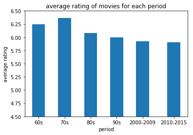

```python
plt.bar([1,2,3,4,5,6.2],period_mean,tick_label=period_mean.index,width=0.5);
plt.title('average rating of movies for each period');
plt.xlabel('period');
plt.ylabel('average rating');
plt.ylim(4.5,6.5);
```

> for the second question we want to know if there is association between some variables and the rating, the variables are the popularity and budget.

### Research Question 2 (finding relations between variables and the rating)

> first we will see if there is relation between popularity and rating

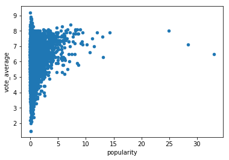

```python
df.plot(x='popularity',y='vote_average',kind='scatter');
```

> it seems that most movies have popularity below 3, so we will take a closer look at the data where popularity is less than 3 to see the relation clearly

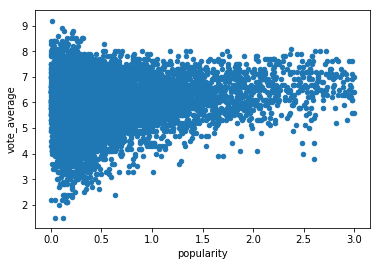

```python
popularity_less3=df.query('popularity<3')
popularity_less3.plot(x='popularity',y='vote_average',kind='scatter');
```

> there is no correlation between the popularity and the averge rating.

> now let's look at the association between the budget and average voting. to make it fair we will use "budget_adj" variable instead of "budget" because it shows the budget in terms of 2010 dollars.

```python
df.tail()
```

|  | id | popularity | original_title | vote_average | release_year | budget_adj | period |
| --- | --- | --- | --- | --- | --- | --- | --- |
| 10861 | 21 | 0.080598 | The Endless Summer | 7.4 | 1966 | 0.000000 | 60s |
| 10862 | 20379 | 0.065543 | Grand Prix | 5.7 | 1966 | 0.000000 | 60s |
| 10863 | 39768 | 0.065141 | Beregis Avtomobilya | 6.5 | 1966 | 0.000000 | 60s |
| 10864 | 21449 | 0.064317 | What's Up, Tiger Lily? | 5.4 | 1966 | 0.000000 | 60s |
| 10865 | 22293 | 0.035919 | Manos: The Hands of Fate | 1.5 | 1966 | 127642.279154 | 60s |

> as you can see above, some movies' budget were setted as zero, we will drop all movies with zero budget.

```python
zero_budget=df.query('budget_adj==0')
df=df.drop(zero_budget.index)
```

> now let's see if there is association between the budget and rating.

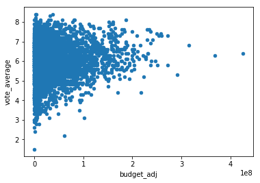

```python
df.plot(x='budget_adj',y='vote_average',kind='scatter');
```

> there is no correlation between the budget and the rating.

## Conclusions

> after we saw the plots, we found that the 70s period has the highest average rating which is equal to 6.36 . this result might be inaccurate because the number of older movies is less than the recent ones in this database.

> we have also found that there is no correlation between the budget of a movie and its rating, it is also the same for the popularity of a movie and its rating. higher popularity and budget were not associated with higher movie rating.

```python
from subprocess import call
call(['python', '-m', 'nbconvert', 'Investigate_a_Dataset.ipynb'])
```